# Revision: Differential Expression Analysis

Ramon Massoni-Badosa

3/3/2020

# 1 Introduction

The objective of this notebook is to directly compare the sampling time-associated transcriptomic signature with the ones reported in the following papers (as requested by reviewer #2):

1. [Baechler EC](https://www.nature.com/articles/6364098), Batliwalla FM, Karypis G, Gaffney PM, Moser K, Ortmann WA, *et al*. Expression levels for many genes in human peripheral blood cells are highly sensitive to ex vivo incubation. Genes Immun. 2004;5:347–53.
2. [Brink SC van den](https://www.nature.com/articles/nmeth.4437), Sage F, Vértesy Á, Spanjaard B, Peterson-Maduro J, Baron CS, *et al*. Single-cell sequencing reveals dissociation-induced gene expression in tissue subpopulations.Nat Methods. 2017;14:935–6.

**Note**: Initially, we also aimed to compare it with the study by [Dvinge *et al.*](https://www.pnas.org/content/111/47/16802), which studied the effect of sampling time on leukimic bulk RNA-seq profiles. However, we could only find the log fold-changes, whose ranking did not reflect the signature they report. Thus, we excluded it from our comparison.

Finally, reviewer #2 pointed out that the number of differentially expressed genes (DEG) reported and the magnitude of the log fold-changes was very small. We discuss this in more detail below in light of the new analysis.

# 2 Pre-processing

## 2.1 Load packages

```r
library(scater)
library(Seurat)
library(ggpubr)
library(purrr)
library(kBET)
library(readxl)
library(AnnotationDbi)
library(org.Hs.eg.db)
library(annaffy)
library(moe430b.db)
library(biomaRt)
library(pheatmap)
library(viridis)
library(cowplot)
library(ggrepel)
library(VennDiagram)
library(tidyverse)
```

## 2.2 Source script

```r
source("bin/utils.R")
```

## 2.3 Load data

```r
# PBMC
pbmc <- readRDS("../1-PBMC/results/R_objects/10X_pbmc_Seurat_clustered.RDS")
pbmc <- subset(pbmc, subset = condition %in% c("0h", "2h", "8h", "24h_RT", "48h_RT"))
pbmc$time <- factor(pbmc$condition, levels = c("0h", "2h", "8h", "24h_RT", "48h_RT"))
levels(pbmc$time) <-  c("0h", "2h", "8h", "24h", "48h")
Idents(pbmc) <- "cell_type"

# CLL
cll <- readRDS("../2-CLL/results/R_objects/cll_seurat_annotated.rds")
cll <- subset(cll, temperature == "RT")

# Get signatures
pbmc_signature_all <- readRDS("../1-PBMC/results/R_objects/cold_shock_signature.rds")
pbmc_signature_up <- readRDS("../1-PBMC/results/R_objects/cold_shock_signature_up.rds")
cll_signature_all <- readRDS("../2-CLL/results/R_objects/cold_shock_signature_all.rds")
cll_signature_up <- readRDS("../2-CLL/results/R_objects/cold_shock_signature_up.rds")
```

# 3 Define signatures other datasets

## 3.1 Load and pre-process data from other studies

```r
# Baechler
excel_sheets("data/41435_2004_BF6364098_MOESM1_ESM.xls")
```

```
## [1] "Supp. table 1" "Supp. table 2" "Supp. table 3"
```

```r
baechler <- read_excel(
  "data/41435_2004_BF6364098_MOESM1_ESM.xls",
  sheet = "Supp. table 2",
  skip = 1
)
baechler <- dplyr::select(baechler, "Probe Set", "Acc. Number", "Gene", "Fold change", "p-value")
colnames(baechler) <- c("probe_set", "acc_number", "gene", "fold_change", "p_value")

# van den Brink
van_den_brink <- read_excel(
  "data/41592_2017_BFnmeth4437_MOESM3_ESM.xlsx",
  sheet = "Fig1a"
)
```

## 3.2 Calculate signatures

```r
####BAECHLER####
baechler <- baechler %>%
  filter(p_value < 0.001) %>%
  arrange(desc(abs(fold_change)))
baechler_signature <- baechler$acc_number[1:250]
baechler_signature <- AnnotationDbi::select(
  org.Hs.eg.db,
  keytype = "ACCNUM",
  columns = "SYMBOL",
  keys = baechler_signature
)
baechler_signature <- baechler_signature[match(unique(baechler_signature$ACCNUM), baechler_signature$ACCNUM), ]

# Curate the NA manually
na_accnum <- baechler_signature$ACCNUM[is.na(baechler_signature$SYMBOL)]
baechler <- as.data.frame(baechler)
# rownames(baechler) <- baechler$acc_number
na_gene_descr <- baechler[baechler$acc_number %in% na_accnum, "gene"]

# Search missing accession numbers in uniprot 1 by 1 (44 in total)
# Verify with gene info of the baechler metadata
symbols_replace <- c("ADORA2A", "CCR2", "JUN", "HSPA1A", "CALR", "CD28",
                     "TRAV8-6", "HSPA1B", "MICA", "ZSCAN9", "LRRN3", NA,
                     "LIN37", "ZEB1", "MINA", NA, NA, "TNFRSF17", "FAM50B",
                     NA, "ACSL4", "FUS", NA, "BCL11A", "GPLD1", NA, "H1-4",
                     "IFNAR2", NA, NA, "RANBP9", "NUP98", "SEC23IP", "RRAS2",
                     NA, NA, "BRCA1", "CD59", "CCR6", "LRIG1", "TRAC", NA, "METTL3", NA)
baechler_signature$SYMBOL[is.na(baechler_signature$SYMBOL)] <- symbols_replace
baechler_signature <- baechler_signature$SYMBOL[!is.na(baechler_signature$SYMBOL)]
# saveRDS(baechler_signature, "results/R_objects/baechler_signature.rds")

####van den Brink####
van_den_brink_signature <- van_den_brink$GeneName[van_den_brink$padj < 0.001]
van_den_brink_signature <- str_remove(van_den_brink_signature, "__chr.*$")
van_den_brink_signature <- convertMouseGeneList(van_den_brink_signature)
# saveRDS(van_den_brink_signature, "results/R_objects/van_den_brink_signature.rds")
```

## 3.3 Find direction (up- or down-regulated)

```r
# Ours
our_signatures <- list(pbmc = pbmc_signature_all, cll = cll_signature_all)
our_signatures_up <- list(pbmc = pbmc_signature_up, cll = cll_signature_up)
our_signs_df <- purrr::map2(our_signatures, our_signatures_up, function(sign, sign_up) {
  direct <- ifelse(sign %in% sign_up, "up-regulated", "down-regulated")
  df <- data.frame(gene = sign, direction = direct)
  df
})

# van den Brink (all up)
van_den_brink_df <- data.frame(
  gene = van_den_brink_signature,
  direction = rep("up-regulated", length(van_den_brink_signature))
)

# Baechler
baechler_accnum <- AnnotationDbi::select(
  org.Hs.eg.db,
  keytype = "SYMBOL",
  columns = "ACCNUM",
  keys = baechler_signature
)
baechler_accnum <- baechler_accnum[baechler_accnum$ACCNUM %in% baechler$acc_number, ]
baechler_selected <- baechler[baechler$acc_number %in% baechler_accnum$ACCNUM, c("acc_number", "fold_change")]
baechler_accnum$fold_change <- purrr::map_dbl(baechler_accnum$ACCNUM, function(x) {
  fc <- baechler_selected[baechler_selected$acc_number == x, "fold_change"][1]
  fc
})
baechler_accnum <- baechler_accnum[match(unique(baechler_accnum$SYMBOL), baechler_accnum$SYMBOL), ]
baechler_direct <- purrr::map_chr(baechler_signature, function(x) {
  if (x %in% baechler_accnum$SYMBOL) {
    direct <- ifelse(
      baechler_accnum$fold_change[baechler_accnum$SYMBOL == x] > 0,
      "up-regulated",
      "down-regulated"
    )
    direct
  } else {
    NA
  }
})
names(baechler_direct) <- baechler_signature
curate_manually <- names(baechler_direct)[is.na(baechler_direct)]
curate_manually_direct <- c("down-regulated", "up-regulated", "down-regulated",
                            "down-regulated", "down-regulated", "down-regulated",
                            "down-regulated", "up-regulated", "down-regulated",
                            "down-regulated", "NA", "NA", "NA", "down-regulated",
                            "NA", "NA", "NA", "down-regulated", "downregulated",
                            "up-regulated", "down-regulated", "down-regulated",
                            "down-regulated", "NA", "down-regulated", "down-regulated",
                            "down-regulated", "NA", "down-regulated", "NA")
names(baechler_direct) <- NULL
baechler_direct[is.na(baechler_direct)] <- curate_manually_direct
baechler_signature_df <- data.frame(
  gene = baechler_signature,
  direction = baechler_direct
)

# Save
signatures_dfs <- list(
  PBMC = our_signs_df$pbmc,
  CLL = our_signs_df$cll,
  "van den Brink" = van_den_brink_df,
  Baechler = baechler_signature_df
)
DT::datatable(signatures_dfs$PBMC)
```

|  | gene | direction |
| --- | --- | --- |
| 1 | FTH1 | up-regulated |
| 2 | EIF1 | up-regulated |
| 3 | SERF2 | down-regulated |
| 4 | TMSB10 | down-regulated |
| 5 | CORO1A | down-regulated |
| 6 | MYL12A | down-regulated |
| 7 | TMSB4X | down-regulated |
| 8 | CD52 | down-regulated |
| 9 | ACTB | down-regulated |
| 10 | IL32 | down-regulated |

[output cut: 238 more lines]

```r
DT::datatable(signatures_dfs$CLL)
```

|  | gene | direction |
| --- | --- | --- |
| 1 | TSC22D3 | up-regulated |
| 2 | CXCR4 | up-regulated |
| 3 | PMAIP1 | up-regulated |
| 4 | SF1 | up-regulated |
| 5 | TXNIP | up-regulated |
| 6 | EIF1 | up-regulated |
| 7 | CIRBP | up-regulated |
| 8 | UBC | up-regulated |
| 9 | TMSB4X | down-regulated |
| 10 | SRSF5 | down-regulated |

[output cut: 190 more lines]

```r
DT::datatable(signatures_dfs$`van den Brink`)
```

|  | gene | direction |
| --- | --- | --- |
| 1 | CEBPB | up-regulated |
| 2 | ID3 | up-regulated |
| 3 | JUND | up-regulated |
| 4 | FOS | up-regulated |
| 5 | HSPB1 | up-regulated |
| 6 | DNAJB1 | up-regulated |
| 7 | HSPA8 | up-regulated |
| 8 | DUSP1 | up-regulated |
| 9 | EGR1 | up-regulated |
| 10 | CEBPD | up-regulated |

[output cut: 17 more lines]

```r
DT::datatable(signatures_dfs$Baechler)
```

|  | gene | direction |
| --- | --- | --- |
| 1 | ID1 | up-regulated |
| 2 | ADORA2A | down-regulated |
| 3 | CDC42 | up-regulated |
| 4 | GPKOW | down-regulated |
| 5 | PHLDA2 | up-regulated |
| 6 | ARMC8 | down-regulated |
| 7 | MFAP3 | down-regulated |
| 8 | GART | down-regulated |
| 9 | ZNF175 | down-regulated |
| 10 | KEAP1 | down-regulated |

[output cut: 222 more lines]

```r
# openxlsx::write.xlsx(signatures_dfs, "results/tables/gene_expression_signatures_comparison.xlsx")
```

## 3.4 Venn Diagram

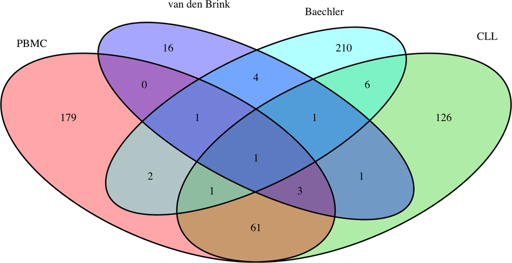

```r
signatures <- purrr::map(signatures_dfs, "gene")
venn <- venn.diagram(
  signatures,
  fill = 2:5,
  alpha = 0.35,
  filename = NULL,
  cat.just = list(c(0.6,1), c(0,0), c(0,0), c(1,1))
)
grid.draw(venn)
```

## 3.5 Heatmap

Select genes that intersect in at least two datasets:

```r
# Find genes to plot (at least in two signatures, unifying ours (PBMC + CLL)
ours_union <- Reduce(union, list(signatures$PBMC, signatures$CLL))
signatures_heat <- list(
  ours_union,
  signatures$Baechler,
  signatures$`van den Brink`
)
all_genes <- Reduce(union, signatures_heat)
n_genes_in_sign_l <- purrr::map_int(all_genes, function(gene) {
  sum(purrr::map_int(signatures_heat, ~gene %in% .x))
})
selected_genes <- all_genes[n_genes_in_sign_l >= 2]
```

Plot heatmap

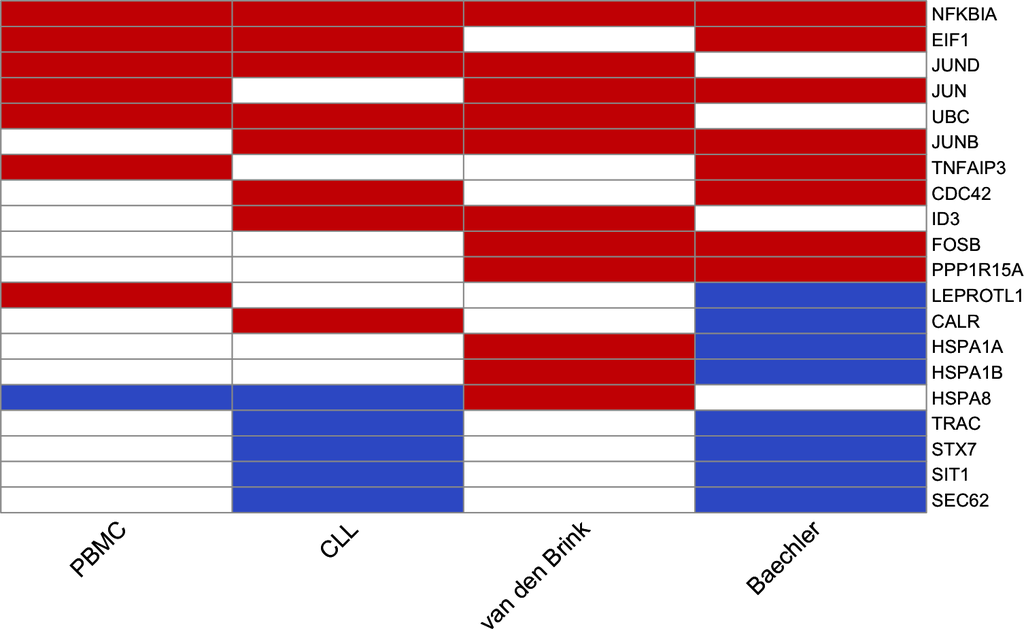

```r
heatmap_row_list <- purrr::map(selected_genes, function(gene) {
  heat_row <- purrr::map_dbl(signatures_dfs, function(df) {
    if (!(gene %in% df$gene)) {
      0
    } else if (df[df$gene == gene, "direction"] == "up-regulated") {
      1
    } else {
      -1
    }
  })
  heat_row
})
heat_mat <- Reduce(rbind, heatmap_row_list)
rownames(heat_mat) <- selected_genes
cols <- c("royalblue3", "white", "red3")
heat_mat <- heat_mat[order(rowSums(heat_mat), decreasing = TRUE), ]
heatmap_signatures <- pheatmap(
  heat_mat,
  cluster_rows = FALSE,
  cluster_cols = FALSE,
  color = cols,
  legend = FALSE,
  angle_col = 45,
  fontsize_col = 13
)
print(heatmap_signatures)
```

# 4 Compute cell-specific scores for each signature

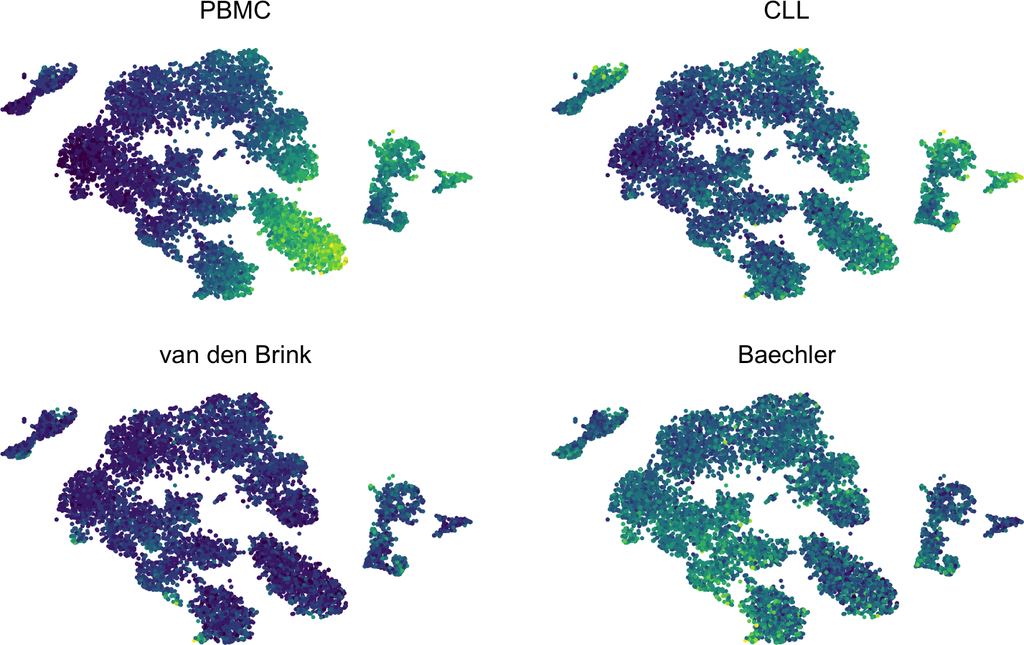

```r
names(signatures)[3] <- "van_den_Brink"
purrr::walk2(signatures, names(signatures), function(sign, x) {
  pbmc <<- AddModuleScore(pbmc, features = list(sign), name = x)
})

# Plot tsnes
titles <- c("PBMC", "CLL", "van den Brink", "Baechler")
tsnes_signatures <- purrr::map2(names(signatures), titles, function(x, y) {
  tsne <- FeaturePlot(
    pbmc,
    features = str_c(x, "1", sep = ""),
    pt.size = 0.35,
    reduction = "tsne",
    cols = viridis(10))
  tsne +
    ggtitle(y) +
    theme(plot.title = element_text(size = 13, face = "plain"),
          axis.title = element_blank(),
          axis.text = element_blank(),
          axis.ticks = element_blank(),
          axis.line = element_blank())
})
leg <- as_ggplot(get_legend(tsnes_signatures[[1]]))
# ggsave(filename = "../doc/figures/legends/tsne_signatures_comparison.pdf", height = 4, width = 4)
tsnes_signatures <- ggarrange(
  plotlist = tsnes_signatures,
  nrow = 2,
  ncol = 2,
  legend = "none"
)
tsnes_signatures
```

As we can observe, there is a large overlapping in the upregulation of key stress-related genes, namely NFKBIA, JUN, JUND or FOSB. However, there is a poor global intersection, which indicates the following:

- Different stressors lead to different transcriptomic signatures (treatment with collagenase VS sampling time).
- Different technologies have different sensitivity/specificity to measure transcriptomic changes associated with a condition (Baechler vs ours).

## 4.1 Arrange figure

```r
# colnames(heat_mat) <- NULL
# heatmap_signatures <- pheatmap(
#   heat_mat,
#   cluster_rows = FALSE,
#   cluster_cols = FALSE,
#   color = cols,
#   angle_col = 45,
#   legend = FALSE
# )
names(signatures) <- c("", "", "", "")
venn_no_labels <- venn.diagram(
  signatures,
  fill = 2:5,
  alpha = 0.35,
  filename = NULL
)
# fig <- plot_grid(as_ggplot(venn_no_labels), heatmap_signatures[[4]],
#                  tsnes_signatures, nrow = 2)
# fig
fig_row1 <- plot_grid(as_ggplot(venn_no_labels), NULL, heatmap_signatures[[4]],
                      ncol = 3, rel_widths = c(0.65, 0.025, 0.45))
fig_row2 <- tsnes_signatures
fig <- plot_grid(fig_row1, fig_row2, nrow = 2, rel_heights = c(0.45, 0.55))
# ggsave(plot = fig, filename = "../doc/figures/R/suppZ.pdf", width = 18, height = 23, units = "cm")
```

# 5 P-values and log (fold-changes)

In the manuscript, we argue that sampling time induces a downregulation of gene expression, which leads to a time-dependent reduction in the number of detected genes. Reviewer #2 questioned this claim by arguing that >200 DEG cannot be considered a global effect. Although this is a valid point, we especulate that this is because of the default logFC parameter of the `FindMarkers()` function, which only tests for differential expression if a gene has a minimal logFC of 0.25. As a global effect entails subtle changes to the majority of genes, we will set this parameter to 0 and recompute the DEG. Finally, we will also recompute the log fold-changes, as we previously used a pseudocount too large for the sparse nature of scRNA-seq data:

```r
# New DEA setting logfc.threshold to 0 to detecte more subtle effects
pbmc_types <- SplitObject(pbmc, split.by = "cell_type")
seurat_list <- list(pbmc = pbmc, cll = cll)
seurat_list <- c(seurat_list, pbmc_types)
seurat_list <- seurat_list[c("pbmc", "cll", "T", "NK", "Monocyte", "B")]
names(seurat_list) <- c("PBMC", "CLL", "T-cell", "NK", "Monocyte", "B-cell")
seurat_list <- purrr::map(seurat_list, function(seurat) {
  seurat$is_biased <- ifelse(seurat$time %in% c("0h", "2h"), "unbiased", "biased")
  Idents(seurat) <- "is_biased"
  seurat
})
dea_list <- purrr::map(seurat_list, function(seurat) {
  dea_df <- FindMarkers(
    seurat,
    ident.1 = "biased",
    ident.2 = "unbiased",
    test.use = "wilcox",
    logfc.threshold = 0
  )
  dea_df
})
dea_df_l <- purrr::map2(dea_list, seurat_list, function(df, seurat) {
  mat <- as.matrix(seurat[["RNA"]]@data[rownames(df), ])
  average_expression <- rowMeans(mat)
  log2_fc <- apply(mat, 1, function(x) {
    mean_biased <- mean(x[seurat$is_biased == "biased"]) + 0.05
    mean_unbiased <- mean(x[seurat$is_biased == "unbiased"]) + 0.05
    log2(mean_biased / mean_unbiased)
  })
  df <- df %>%
    rownames_to_column(var = "gene") %>%
    dplyr::select("gene", "p_val", "p_val_adj") %>%
    dplyr::mutate(average_expression = average_expression, log2_fc = log2_fc) %>%
    dplyr::arrange(p_val_adj) %>%
    dplyr::filter(p_val_adj < 0.001)
  df <- df[, c("gene", "average_expression", "log2_fc", "p_val", "p_val_adj")]
  df
})
DT::datatable(dea_df_l$PBMC)
```

|  | gene | average_expression | log2_fc | p_val | p_val_adj |
| --- | --- | --- | --- | --- | --- |
| 1 | FTH1 | 2.83456073776848 | 0.591611622556802 | 0 | 0 |
| 2 | EIF1 | 2.53654664303694 | 0.385224066963493 | 0 | 0 |
| 3 | SERF2 | 1.39204262366535 | -0.840913282141152 | 0 | 0 |
| 4 | TMSB10 | 3.19888213071331 | -0.408051267725766 | 0 | 0 |
| 5 | CORO1A | 0.838052957428947 | -1.26440612960717 | 0 | 0 |
| 6 | MYL12A | 1.35866519687749 | -0.879138064017457 | 0 | 0 |
| 7 | TMSB4X | 4.75823512752019 | -0.327729021357657 | 0 | 0 |
| 8 | CD52 | 1.53275763915577 | -1.11314794630194 | 0 | 0 |
| 9 | ACTB | 2.78888251813018 | -0.705056956231403 | 0 | 0 |
| 10 | IL32 | 1.22817634174462 | -1.18960238013236 | 0 | 0 |

[output cut: 1175 more lines]

```r
DT::datatable(dea_df_l$CLL)
```

|  | gene | average_expression | log2_fc | p_val | p_val_adj |
| --- | --- | --- | --- | --- | --- |
| 1 | TSC22D3 | 1.45256868078229 | 0.861893584211178 | 0 | 0 |
| 2 | CXCR4 | 1.63206343344494 | 0.803145616650096 | 0 | 0 |
| 3 | PMAIP1 | 0.989763978122031 | 1.01877298608463 | 0 | 0 |
| 4 | SF1 | 1.73075183425417 | 0.585878742283223 | 0 | 0 |
| 5 | TXNIP | 2.90948912213368 | 0.301314367077173 | 0 | 0 |
| 6 | EIF1 | 2.99355808254666 | 0.248883859139377 | 0 | 0 |
| 7 | CIRBP | 1.79041503589693 | 0.397455561887088 | 0 | 0 |
| 8 | UBC | 2.17773985974763 | 0.28942887276599 | 0 | 0 |
| 9 | TMSB4X | 3.11009753537592 | -0.23121249526637 | 0 | 0 |
| 10 | SRSF5 | 1.66973507514573 | -0.417903643594276 | 0 | 0 |

[output cut: 1858 more lines]

```r
DT::datatable(dea_df_l$`T-cell`)
```

|  | gene | average_expression | log2_fc | p_val | p_val_adj |
| --- | --- | --- | --- | --- | --- |
| 1 | TMSB4X | 4.50105942484566 | -0.347885763360633 | 0 | 0 |
| 2 | ACTB | 2.34539521628129 | -0.785003570013744 | 0 | 0 |
| 3 | PFN1 | 1.39346217612244 | -1.27041114974982 | 0 | 0 |
| 4 | IL32 | 1.41496050678952 | -1.21367155413688 | 0 | 0 |
| 5 | CD52 | 1.68255088379721 | -1.22680895022028 | 0 | 0 |
| 6 | B2M | 4.97428792838983 | -0.215157766166818 | 4.70340773943671e-304 | 4.61075060696981e-300 |
| 7 | FTH1 | 2.45475872517193 | 0.633142413505483 | 7.51450301288019e-299 | 7.36646730352645e-295 |
| 8 | EIF1 | 2.38258977288127 | 0.434996647557891 | 2.45941285506903e-274 | 2.41096242182417e-270 |
| 9 | TMSB10 | 3.00552348935259 | -0.379361727620657 | 5.24706964209986e-256 | 5.14370237015049e-252 |
| 10 | SERF2 | 1.1149412082555 | -0.953184798513932 | 1.38786141456505e-248 | 1.36052054469812e-244 |

[output cut: 935 more lines]

```r
DT::datatable(dea_df_l$NK)
```

|  | gene | average_expression | log2_fc | p_val | p_val_adj |
| --- | --- | --- | --- | --- | --- |
| 1 | TMSB4X | 5.39435159185277 | -0.276436294914172 | 4.70138150494255e-203 | 4.60876428929518e-199 |
| 2 | PFN1 | 2.75290176187017 | -1.03563235507811 | 3.34692905452308e-202 | 3.28099455214897e-198 |
| 3 | ACTB | 3.61162253240102 | -0.781591518997719 | 4.88784104246315e-173 | 4.79155057392662e-169 |
| 4 | GZMA | 1.95656665310574 | -1.34921183550074 | 6.59248199449881e-169 | 6.46261009920719e-165 |
| 5 | FTH1 | 2.80984954236284 | 0.671878690028416 | 8.2863786658058e-147 | 8.12313700608942e-143 |
| 6 | PRF1 | 1.56556837722463 | -1.53113614211518 | 1.0286065895879e-142 | 1.00834303977302e-138 |
| 7 | TMSB10 | 3.57361466026302 | -0.511729383305255 | 3.22138041050563e-140 | 3.15791921641867e-136 |
| 8 | FCER1G | 1.44843047849351 | -1.59708965874338 | 2.2755462905994e-127 | 2.23071802867459e-123 |
| 9 | MYL12A | 1.92852189916199 | -0.958809844341178 | 1.3913757589123e-109 | 1.36396565646173e-105 |
| 10 | CFL1 | 2.03487439865786 | -0.813845120630203 | 3.66430103048376e-100 | 3.59211430018323e-96 |

[output cut: 584 more lines]

```r
DT::datatable(dea_df_l$Monocyte)
```

|  | gene | average_expression | log2_fc | p_val | p_val_adj |
| --- | --- | --- | --- | --- | --- |
| 1 | G0S2 | 1.19480559583319 | 3.78207246725242 | 2.77541015239478e-131 | 2.7207345723926e-127 |
| 2 | FTH1 | 5.23687588812319 | 0.372979461884976 | 5.14619301016674e-114 | 5.04481300786645e-110 |
| 3 | SRGN | 2.9302551729711 | 0.62627803299546 | 4.19147785674419e-101 | 4.10890574296633e-97 |
| 4 | MNDA | 1.29829440624457 | -1.65229984779204 | 1.19400770454691e-92 | 1.17048575276734e-88 |
| 5 | FGL2 | 0.550194110173447 | -2.42798018309684 | 1.11087860392648e-86 | 1.08899429542912e-82 |
| 6 | TIMP1 | 1.53670276493245 | 1.42131716623025 | 1.53642036759881e-80 | 1.50615288635712e-76 |
| 7 | CALM2 | 1.72961528203538 | -1.01932840337145 | 6.81764856524712e-79 | 6.68334088851175e-75 |
| 8 | IL8 | 0.749847511842963 | 3.414062460338 | 1.99030263253764e-74 | 1.95109367067664e-70 |
| 9 | DYNLL1 | 0.406727212938904 | -2.68843127444149 | 1.37966059764088e-71 | 1.35248128386736e-67 |
| 10 | OAZ1 | 2.06115213488837 | -0.681934341552327 | 3.22543881756039e-70 | 3.16189767285445e-66 |

[output cut: 781 more lines]

```r
DT::datatable(dea_df_l$`B-cell`)
```

|  | gene | average_expression | log2_fc | p_val | p_val_adj |
| --- | --- | --- | --- | --- | --- |
| 1 | TMSB4X | 3.83790070257153 | -0.609704059873844 | 1.52114687775558e-50 | 1.49118028426379e-46 |
| 2 | CD52 | 2.23519621716164 | -1.12579188985262 | 5.13278905504599e-46 | 5.03167311066159e-42 |
| 3 | TMSB10 | 2.87393905615262 | -0.646566345870592 | 3.61561540019435e-33 | 3.54438777681052e-29 |
| 4 | CD79B | 1.02528757518028 | -1.51567472250326 | 2.12518464468621e-29 | 2.08331850718589e-25 |
| 5 | CYBA | 1.33616195885495 | -1.07400740724589 | 2.32563499604289e-28 | 2.27981998662085e-24 |
| 6 | LTB | 1.54969884986059 | -1.15103778230064 | 2.78065949961585e-28 | 2.72588050747342e-24 |
| 7 | TCL1A | 0.657798217627361 | -3.13305437496213 | 1.74131992084705e-26 | 1.70701591840636e-22 |
| 8 | EZR | 0.705474874986182 | 1.55306817440825 | 1.39036914635771e-25 | 1.36297887417447e-21 |
| 9 | OAZ1 | 1.04656589055002 | -1.15296277884012 | 3.44945178920942e-22 | 3.38149758896199e-18 |
| 10 | FTH1 | 2.74896939085086 | 0.45887417150026 | 1.74502477279323e-20 | 1.71064778476921e-16 |

[output cut: 88 more lines]

```r
# openxlsx::write.xlsx(dea_df_l, file = "results/tables/dea_storage_time.xlsx")
```

## 5.1 MA plot

[figure not shown]

```r
sheets <- c("PBMC", "CLL")
xl_path <- "results/tables/dea_storage_time.xlsx"
dea_df_l <- purrr::map(sheets, ~read_excel(xl_path, sheet = .x, skip = 2, col_names = TRUE))
# subset_sig_cll <- readRDS("../2-CLL/results/R_objects/subset_significant_cll.rds")
names(dea_df_l) <- sheets
ma_plot_dfs <- purrr::map2(list(pbmc, cll), dea_df_l, function(seurat, dea_df) {
  seurat$is_biased <- ifelse(seurat$time %in% c("0h", "2h"), "unbiased", "biased")
  mat <- as.matrix(seurat[["RNA"]]@data)
  average_expression <- rowMeans(mat)
  log2_fc <- apply(mat, 1, function(x) {
    mean_biased <- mean(x[seurat$is_biased == "biased"]) + 0.05
    mean_unbiased <- mean(x[seurat$is_biased == "unbiased"]) + 0.05
    log2(mean_biased / mean_unbiased)
  })
  is_significant <- map_lgl(rownames(mat), function(x) {
    if (x %in% dea_df$gene) {
      if (dea_df[dea_df$gene == x, "p_val_adj"] < 0.001) {
        TRUE
      } else {
        FALSE
      }
    } else {
      FALSE
    }
  })
  df <- data.frame(
    average_expression = average_expression,
    log2_fc = log2_fc,
    is_significant
  )
  df
})
names(ma_plot_dfs) <- sheets
ma_plot_gg <- purrr::map(ma_plot_dfs, function(df) {
  ma_plot <- df %>%
    ggplot(aes(log(average_expression + 1), log2_fc, color = is_significant)) +
      geom_point(size = 0.2, alpha = 0.6) +
      geom_smooth(method = "loess", color = "darkblue") +
      geom_hline(yintercept = 0, color = "black", linetype = "dashed") +
      scale_color_manual(values = c("gray78", "green4"), labels = c("sig", "no sig")) +
      labs(x = "log (Average Expression)", y = "log (biased / unbiased)", color = "") +
      theme_classic2() +
      theme(axis.title = element_text(size = 11),
            legend.text = element_text(size = 11),
            plot.title = element_text(hjust = 0.5, face = "bold"))
  ma_plot
})
# saveRDS(ma_plot_gg$PBMC, "results/R_objects/ma_plot_all_types_pbmc.rds")
subset_sig <- dea_df_l$CLL %>%
  dplyr::filter(p_val_adj < 10e-10 & abs(log2_fc) > 0.35 & average_expression > 0.75)
ma_plot_gg$CLL <- ma_plot_gg$CLL +
  geom_text_repel(data = subset_sig, aes(label = gene), color = "black", size = 2.5)
ma_plot_gg$PBMC
```

[figure not shown]

```r
ma_plot_gg$CLL
```

```r
# saveRDS(ma_plot_gg$CLL, "results/R_objects/ma_plot_all_cell_types_cll.rds")
```

Interestingly, we see how now we report >1,000 DEG. Moreover, the vast majority of these DEG are down-regulated, which is in line with our main findings.